# Dados de commits no github

Vinicius Brandão Araújo

```
## Observations: 13,802
## Variables: 5
## $ file_extension <chr> "md", "md", "md", "md", "md", "md", "md", "md",...
## $ month_day      <int> 18, 17, 27, 16, 26, 21, 4, 22, 23, 1, 12, 3, 2,...
## $ the_month      <int> 2, 2, 1, 2, 1, 3, 2, 2, 2, 2, 4, 2, 2, 2, 4, 3,...
## $ the_year       <int> 2016, 2016, 2016, 2016, 2016, 2017, 2016, 2016,...
## $ users          <int> 10279, 10208, 10118, 10045, 10020, 10015, 9991,...
```

## Objetivo da analise.

Esta análise, realizada no contexto da disciplina Ciência de Dados 1, tem por objetivo avaliar a popularidade de linguagens de programação no período entre 2016 e 2017 segundo dados registrados no GitHub. Essa análise serve de mote para trabalharmos conceitos de inferência, intervalos de confiança, significância, entre outros.

## Conhecendo os dados.

Usaremos uma amostra de dados que contém informações sobre quantos usuários fizeram atividade no GitHub. Abaixo podemos observar a distribuição das atividade global no GitHub.

[interactive chart not shown]

### Segunda e sexta têm popularidade menor que terça, quarta e quinta?

Para responder essa pergunta iremos considerar apenas os dias da semana e dividir em dois grupos, o grupo de terça á quinta e de segunda á sexta.

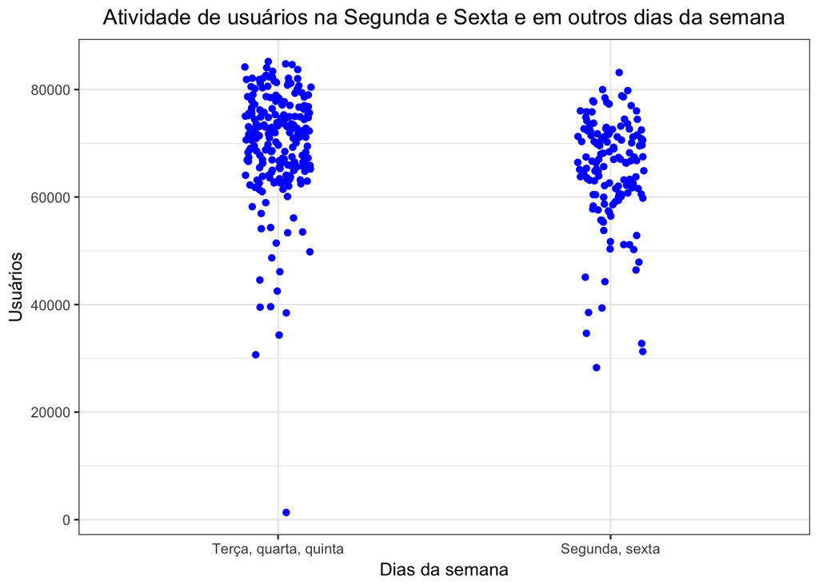

Não conseguimos enchergar uma diferença clara entre os dois grupos, observamos que segunda e sexta tem um numero considerado de atividade, mas não podemos concluir por esse meio visual.Para isso usaremos bootstrap e intervalo de confiança.

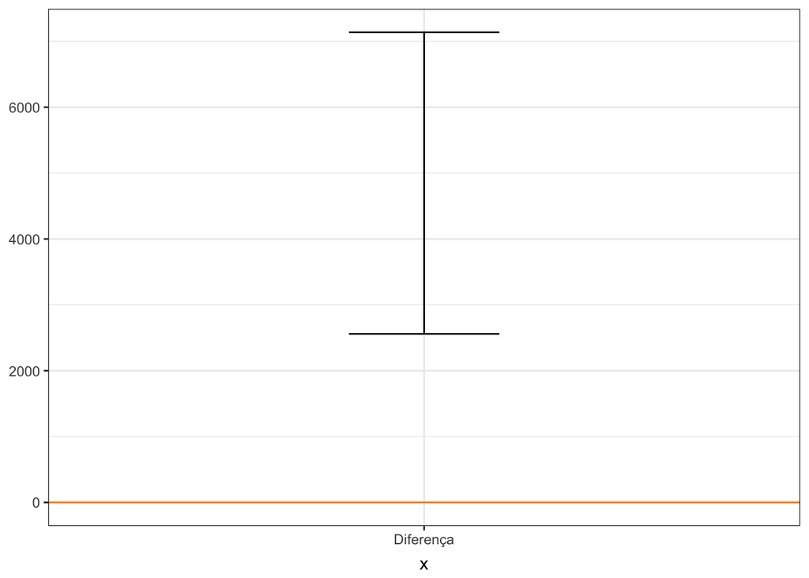

Com 95% de confiança podemos observar que existe uma diferença entre esses dois grupos, baseado nas amostras (utilizando bootstrap), e está diferença tem um intervalo positivo grande, sendo assim a diferença entre Segunda e Sexta e os demais dias da semana é relevante. Podemos associar que segunda e sexta são os pontos extremos da semana e com isso o dias do “meio da semana” como mais produtivos. Com intervalo de confiança, além de conseguirmos identificar se existe diferença das medianas também podemos identificar o intervalo dessa diferença. Ou seja, aplicando essa técnica temos o poder de mensurar o quão relevante é a diferença e não apenas se ela existe ou não.

#### Existe diferença na popularidade entre Segunda e Sexta?

Para responder essa pergunta, iremos considerar apenas segunda e sexta na base de dados.

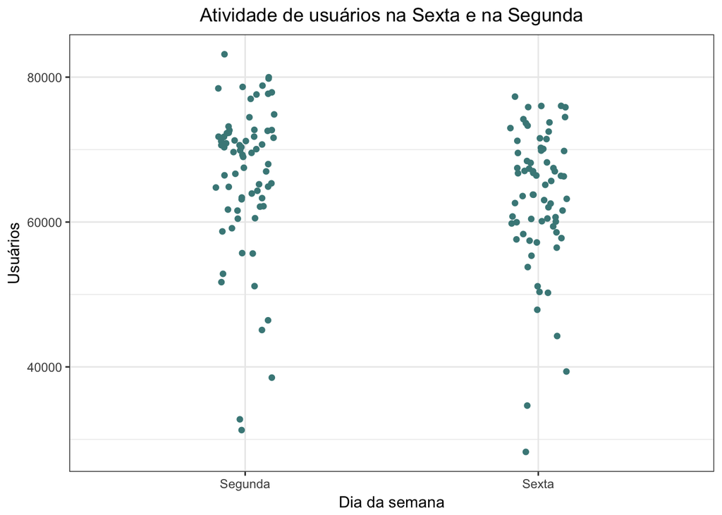

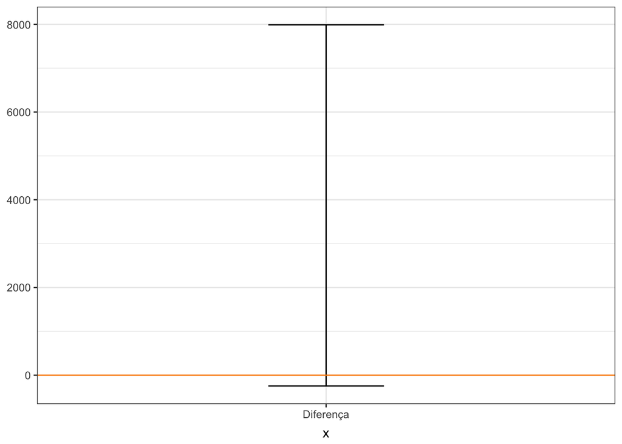

### Período de Ferias(Julho, Dezembro) as atividade do GitHub Cai?

Para responder essa pergunta separamos em dois conjuntos, tomando como referencia de ferias os meses de Julho e Dezembro.

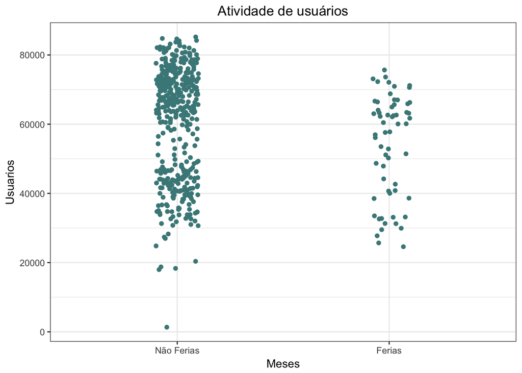

```r
set.seed(123)
dados.github.vocations %>%
  ggplot(aes(x = ferias, y = total)) +
  geom_jitter(width = .1, color = "#488888") +
  labs(title = "Atividade de usuários", x = "Meses", y = "Usuarios") +
  scale_x_discrete(labels= c("Não Ferias", "Ferias")) +
  theme(plot.title = element_text(hjust = 0.5))
```

Como podemos observar acima não tem como definir uma queda em relação ao numero de usuarios nos meses de Dezembro e Julho, mas como sabemos não podemos definir isto como uma conclusão baseada nesta visualização, para melhorar a observação iremos utilizar bootstrap e intervalo de confiança para chegar a uma conclusão.

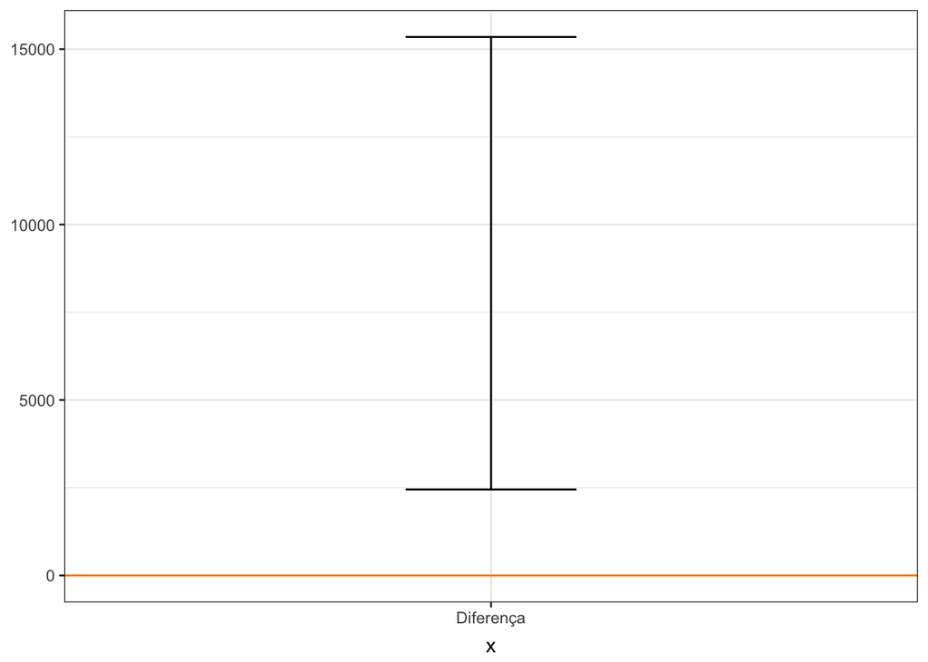